# Intro to R: Visualization Basics

Christina Maimone

2017-09-06

# Setup

If not following directly after previous sections, you may need to load some packages and data.

```r
library(tidyverse)
schooldata <- read_csv("https://goo.gl/f4UhMX")
library(gapminder)
data(gapminder)
```

`gapminder` has information on life expectancy, GDP per capita, and population for countries every 5 years, 1952 to 2007, with countries grouped by continent:

```r
head(gapminder)
```

```
## # A tibble: 6 x 6
##       country continent  year lifeExp      pop gdpPercap
##        <fctr>    <fctr> <int>   <dbl>    <int>     <dbl>
## 1 Afghanistan      Asia  1952  28.801  8425333  779.4453
## 2 Afghanistan      Asia  1957  30.332  9240934  820.8530
## 3 Afghanistan      Asia  1962  31.997 10267083  853.1007
## 4 Afghanistan      Asia  1967  34.020 11537966  836.1971
## 5 Afghanistan      Asia  1972  36.088 13079460  739.9811
## 6 Afghanistan      Asia  1977  38.438 14880372  786.1134
```

# Overview

There are a few different ways to make plots in R. The two most common methods currently are the built-in base R plotting functions and the `ggplot2` package from the tidyverse. There is a third system, from a package called `lattice`, that you might hear of, but we won’t cover that here as it isn’t widely used currently.

I recommend that use `ggplot2` because it gives the most flexibility and polished results most easily. It takes a little bit longer to get the hang of, but once you know the basics, you can make more complicated plots quickly.

This is a very abbreviated intro to data visualization in R. There are more detailed examples and exercises with the [`ggplot` focused workshop](https://github.com/nuitrcs/ggplotworkshop).

There are also lots of specialized visualization packages that build on the basics to do particular tasks.

# Visualization with Base R

Base plotting functions are good for quick exploratory plots, but the defaults aren’t really publication ready. One main criticism of the built in plotting functions is that each type of plot is made in its own way with its own options. We’ll show a few examples here because you’ll see them, and probably want to use them from time to time.

## Histogram

We’ll start by using the `schooldata` and looking at the distribution of grades.

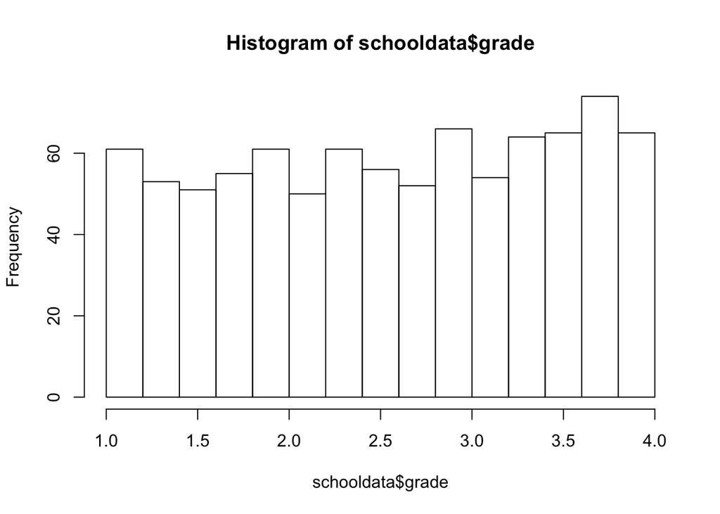

```r
hist(schooldata$grade)
```

We can change the number of bins

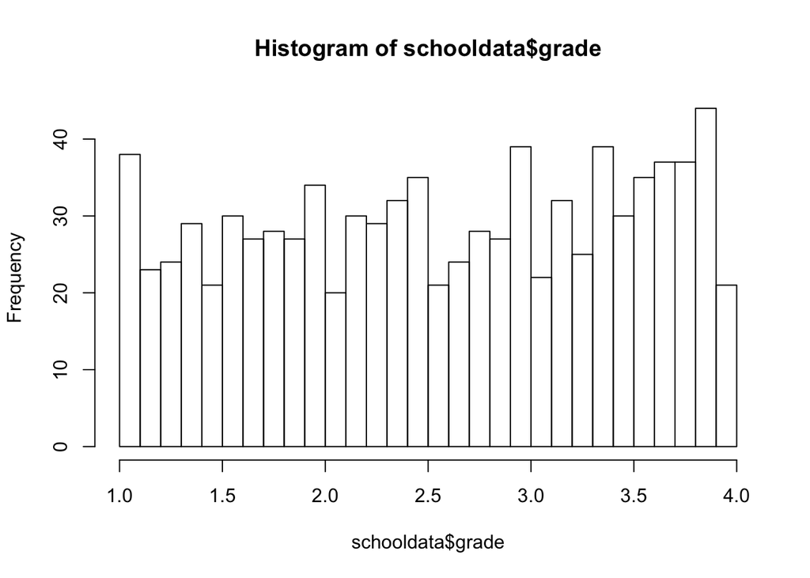

```r
hist(schooldata$grade, breaks=30)
```

You can also change where the breaks are, and the axis limits

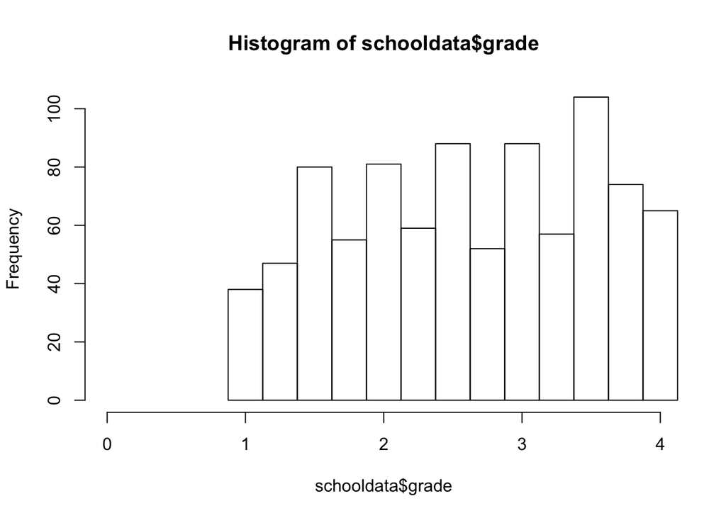

```r
hist(schooldata$grade,
     breaks=seq(.875, 4.125, .25), # where bins break (also determines number)
     xlim=c(0,4)) # xaxis limits
```

And clean up labels

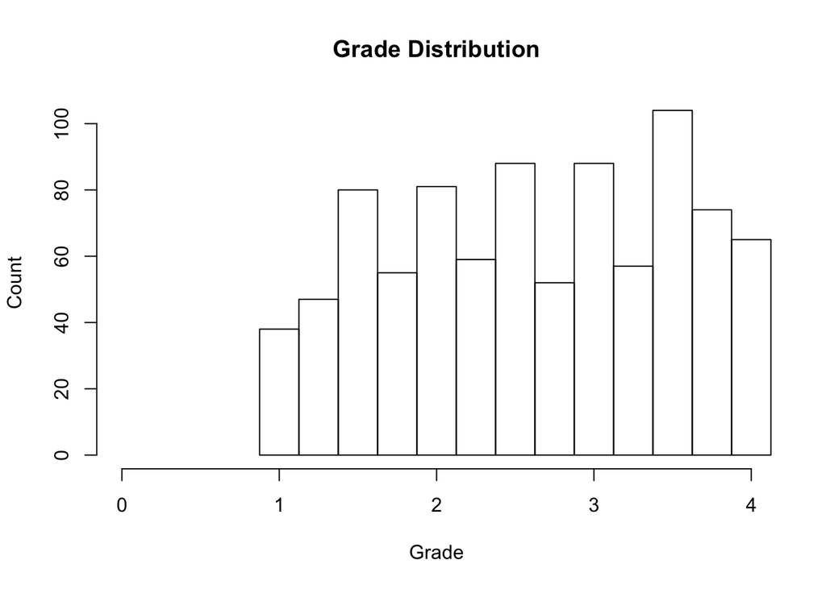

```r
hist(schooldata$grade,
     breaks=seq(.875, 4.125, .25),
     xlim=c(0,4),
     main="Grade Distribution",
     ylab="Count", xlab="Grade")
```

This is a reasonable plot to look at, but we might want to see what the distribution looks like based on course or gender. This can be done, but, with base R, it’s definitely not a topic for a beginner workshop. We’ll return to that with `ggplot`.

## Scatterplot

We’ll use the `gapminder` data here and make a scatterplot of life expectancy and GDP per capita in 2002.

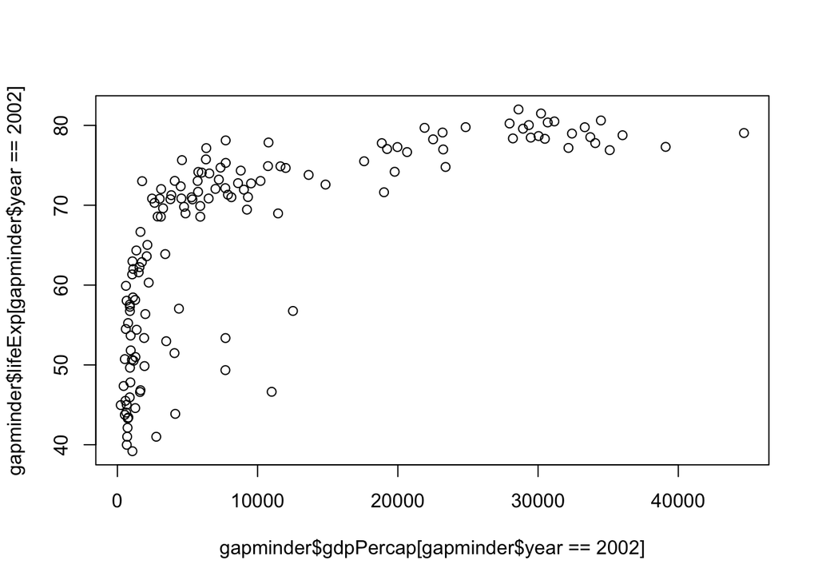

```r
plot(x=gapminder$gdpPercap[gapminder$year==2002],
     y=gapminder$lifeExp[gapminder$year==2002])
```

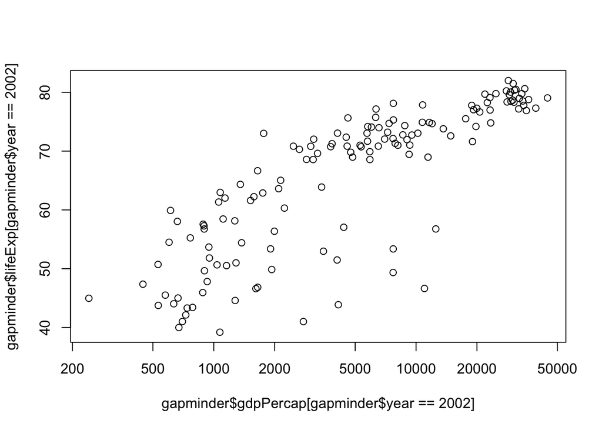

```r
plot(x=gapminder$gdpPercap[gapminder$year==2002],
     y=gapminder$lifeExp[gapminder$year==2002],
     log="x")
```

This `log` argument can be found in the help page for `plot.default`.

We could color points by continent, and add a legend, but that starts to get complicated quickly. We’ll save for `ggplot`.

## Save

There’s an export button in the plot window; otherwise you have to plot to a specific graphics device.

```r
pdf("plot1.pdf", width=6, height=4)
plot(x=gapminder$gdpPercap[gapminder$year==2002],
     y=gapminder$lifeExp[gapminder$year==2002],
     log="x")
dev.off()
```

# `ggplot2`

An essential reference for ggplot is the [Data Visualization with ggplot2 Cheat Sheet](https://www.rstudio.com/wp-content/uploads/2015/03/ggplot2-cheatsheet.pdf). It’s useful to have this handy.

## Histogram

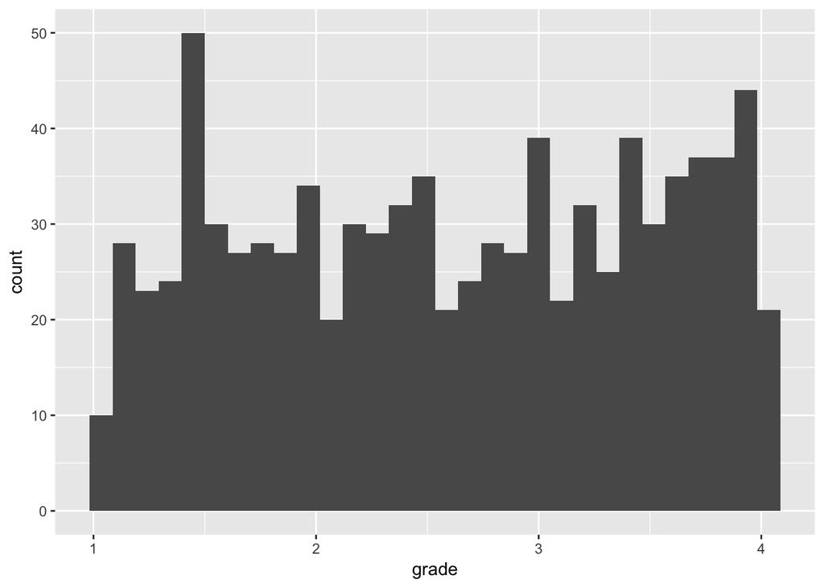

```r
ggplot(schooldata, aes(grade)) + geom_histogram()
```

`ggplot2` works by adding up components of the graph. It starts with a call to `ggplot` specifying which data to use. The first parameter is the name of the data frame, and then in the `aes` function specifies the variables to use. For a histogram, there is just one variable, so you don’t have to specify whether it’s x or y. Then you add on the type of plot you want. In this case, `geom_histogram`.

The call to `ggplot` gave a message that it was using 30 “bins” – this is the number of histogram bars. You can change this:

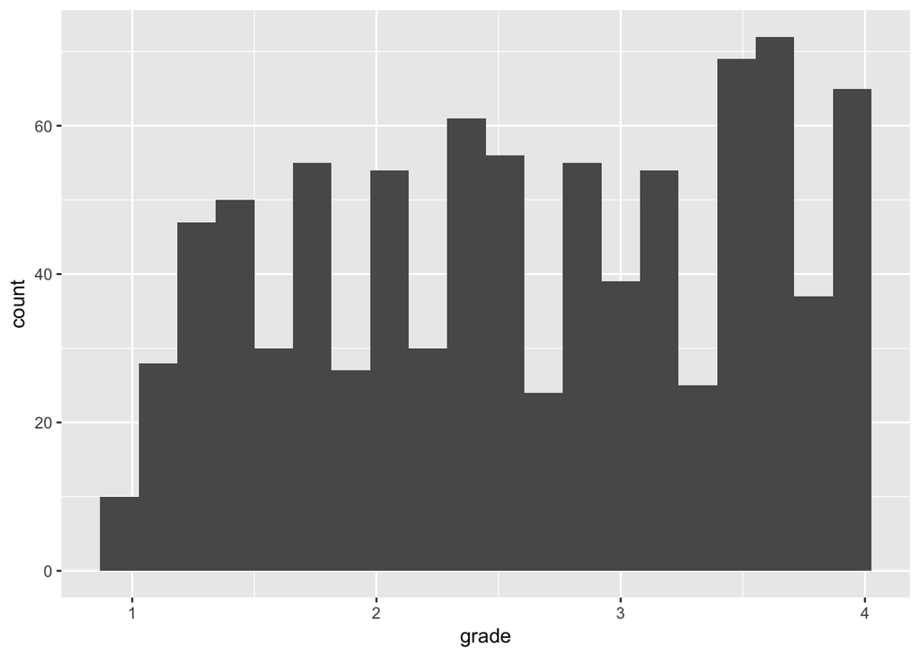

```r
ggplot(schooldata, aes(grade)) + geom_histogram(bins=20)
```

The way that `ggplot` and `hist` delimit their bins, even when there’s the same number of them, are different.

Changing the number of bins (and the cut-offs) makes the pattern in the data look a bit different. Something to be aware of. You can also set the binwidth – say every quarter point here. You can also set the limits of the plot: `NA` in a limit tells ggplot to calculate the upper limit.

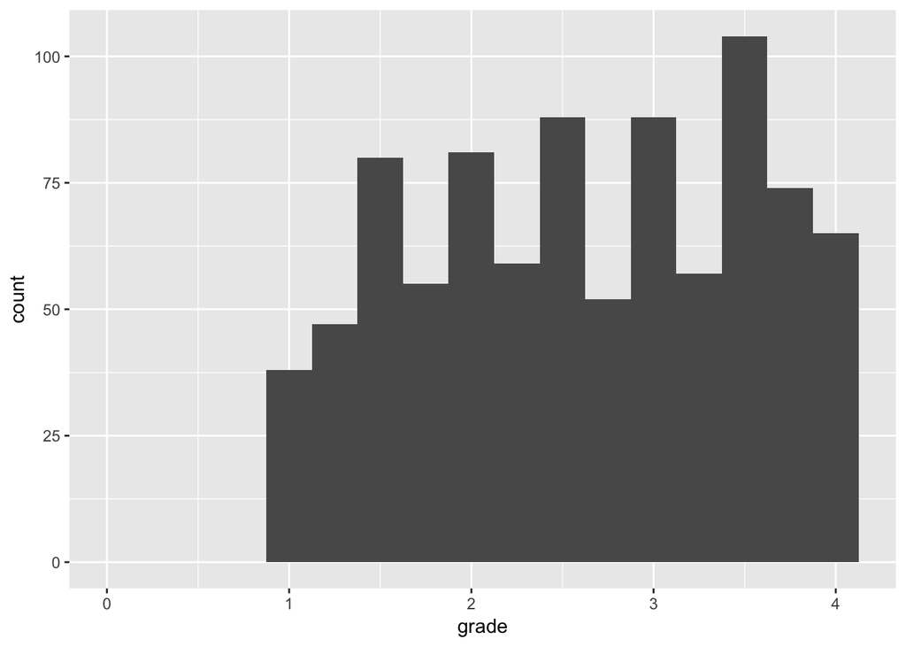

```r
ggplot(schooldata, aes(grade)) +
  geom_histogram(binwidth=.25) +
  xlim(0, NA)
```

In the above plot, you can more clearly see that there are a lot of half and whole grades (1.5, 2, 2.5, 3, etc.). `ggplot` created the bins centered around a whole number (integer) by default.

You can also change the axis labels and add a title:

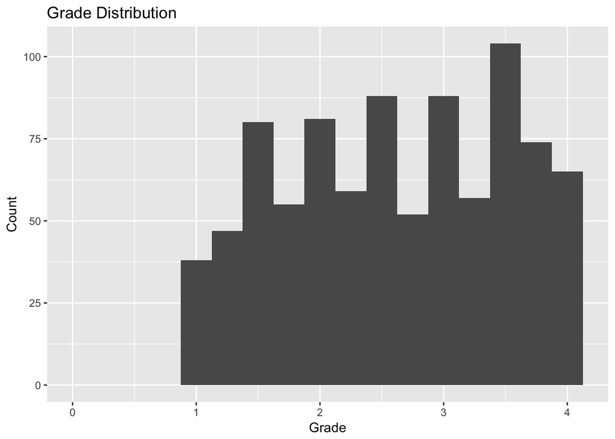

```r
ggplot(schooldata, aes(grade)) +
  geom_histogram(binwidth=.25) +
  xlim(0,NA) +
  xlab("Grade") +
  ylab("Count") +
  ggtitle("Grade Distribution")
```

NOTE: like with `dplyr`, if you’re splitting `ggplot2` commands onto multiple lines, make sure to put the line break after the `+` so that the console knows that more commands are coming that are part of the same plot.

What if you want to see the grade distribution by gender? Add facet grid usign `ggplot`:

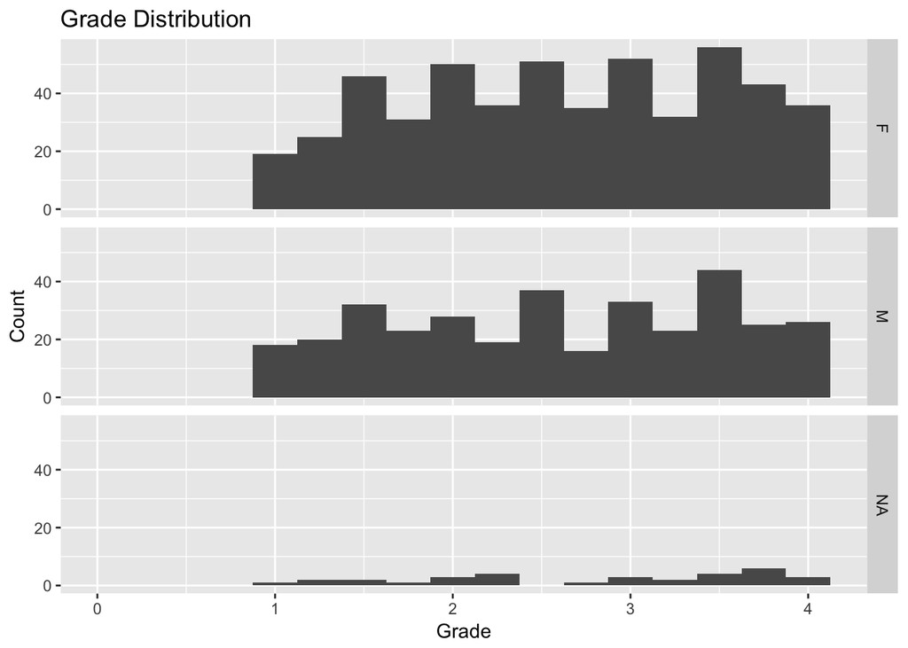

```r
ggplot(schooldata, aes(grade)) +
  geom_histogram(binwidth=.25) +
  xlim(0,NA) +
  xlab("Grade") +
  ylab("Count") +
  ggtitle("Grade Distribution") +
  facet_grid(gender~.)
```

Remove the missing category and change the labels by altering the data being plotted. `facet_grid` makes a factor, so change the levels and labels of the factor. For the missing data, exclude it using `dplyr` functions up front:

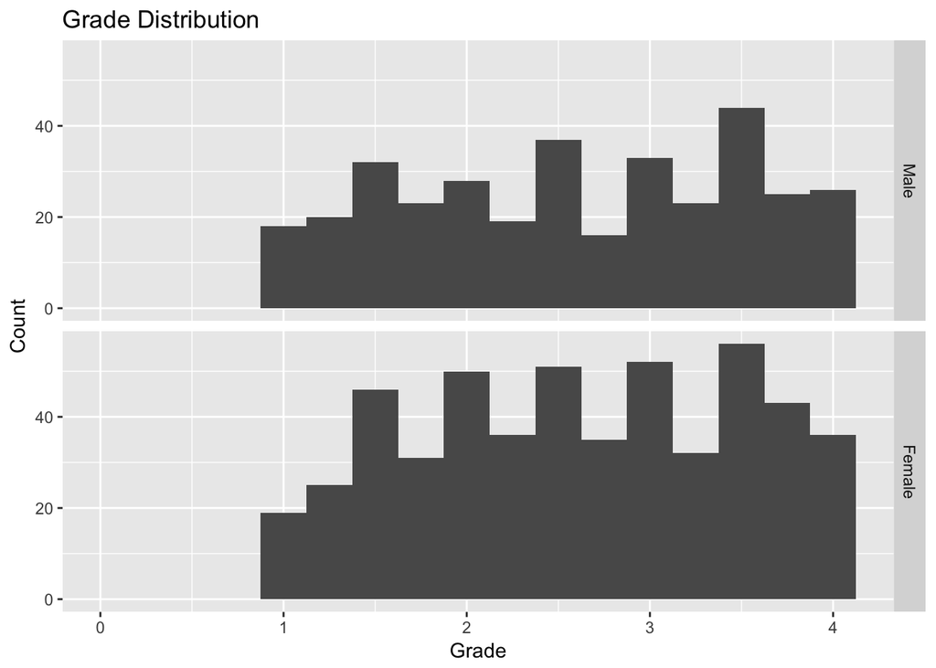

```r
filter(schooldata, !is.na(gender)) %>% # remove missing gender
  mutate(gender=factor(gender, levels=c("M", "F"),
                       labels=c("Male","Female"))) %>% # relabel
  ggplot(aes(grade)) +
  geom_histogram(binwidth=.25) +
  xlim(0,NA) +
  xlab("Grade") +
  ylab("Count") +
  ggtitle("Grade Distribution") +
  facet_grid(gender~.)
```

## Scatter Plot

Again, look at `gdpPercap` (GDP per capita) vs. `lifeExp` (life expectancy) across countries for the year 2002. First select the data, then send it to the plot:

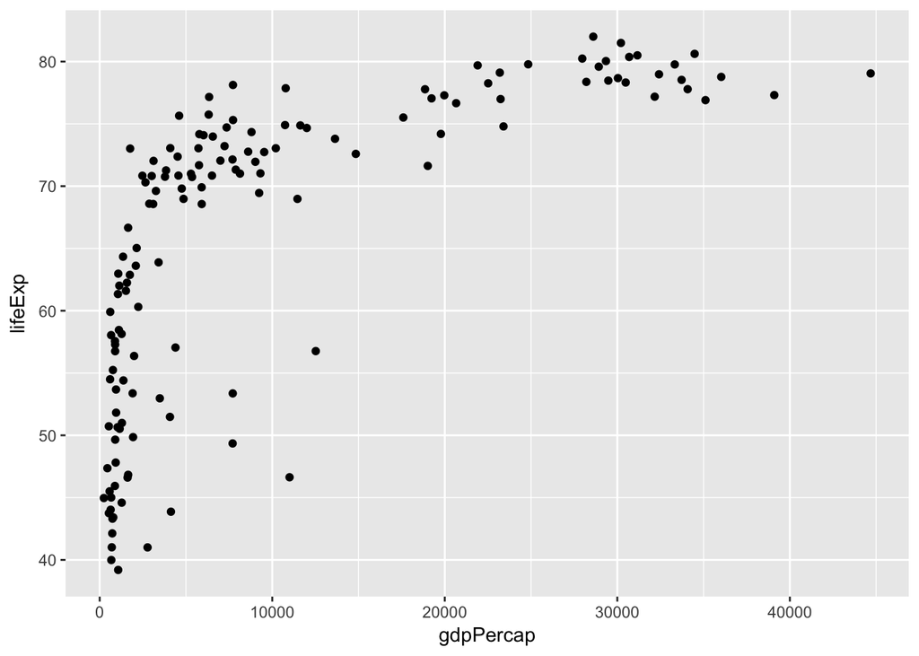

```r
filter(gapminder, year==2002) %>%
  ggplot(aes(x=gdpPercap, y=lifeExp)) + geom_point()
```

This looks like a logarithmic relationship. Change the axis (look at the cheatsheet for reference):

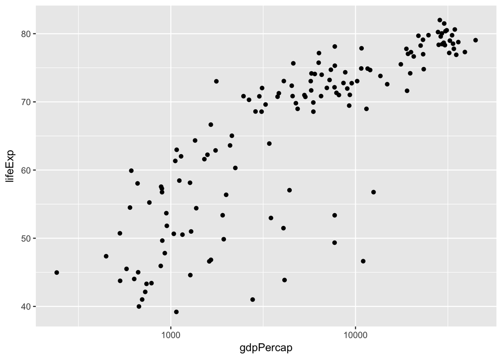

```r
filter(gapminder, year==2002) %>%
  ggplot(aes(x=gdpPercap, y=lifeExp)) +
  geom_point() +
  scale_x_log10()
```

Now it looks more like a linear relationship.

Color the points by continent. Specify the color in the `aes` call (it goes in the `aes` call because you’re plotting a variable using color, much as you are plotting other variables using x and y position):

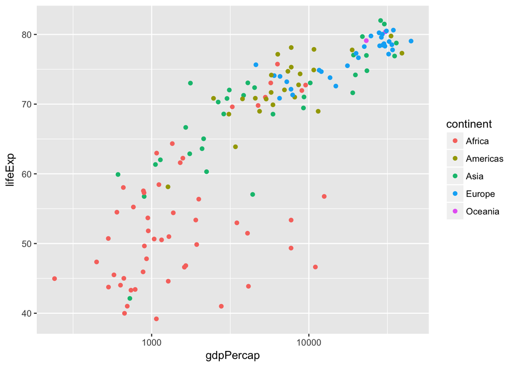

```r
filter(gapminder, year==2002) %>%
  ggplot(aes(x=gdpPercap, y=lifeExp, color=continent)) +
  geom_point() +
  scale_x_log10()
```

## Save

How to save the plot? There’s an export button in the plot window, or use the `ggsave` command to save the last plot we made. It will take the file type from the file name.

```r
ggsave("p1.pdf", width=6, height=4)
```